# Network generation, paths, connectivity

Sean P. Cornelius with Emma K. Towlson and A.-Laszlo Barabasi

- We're going to write our own Erdos-Renyi generation algorithm and use NetworkX to demonstrate some of the concepts and algorithms in the textbook
- Open your IPython notebook and load `networkx`, `numpy`, and `matplotlib` as in the last class

```python
import numpy as np
import networkx as nx
import matplotlib.pyplot as plt
import matplotlib as mpl
%matplotlib inline
```

- Also change the default plot settings so they aren't so heinous

```python
# change defaults to be less ugly
mpl.rc('xtick', labelsize=14, color="#222222")
mpl.rc('ytick', labelsize=14, color="#222222")
mpl.rc('font', **{'family':'sans-serif','sans-serif':['Arial']})
mpl.rc('font', size=16)
mpl.rc('xtick.major', size=6, width=1)
mpl.rc('xtick.minor', size=3, width=1)
mpl.rc('ytick.major', size=6, width=1)
mpl.rc('ytick.minor', size=3, width=1)
mpl.rc('axes', linewidth=1, edgecolor="#222222", labelcolor="#222222")
mpl.rc('text', usetex=False, color="#222222")
```

# Basic data types in Python

## Primitives

Basic math operations are +, -, *, /. For exponentiation, use ** and for integer division use //

```python
# integer
a = 4

# floating point
b = 100.1

# complex
c = 1 + 2j

# string
s = "Hello, world!"

# boolean
t = True
f = False

print(a**2)
print(b/a)
print(b//a)
```

```
16
25.025
25.0
```

## Lists

Basic ordered container. Supports O(1) indexing, adding to/removing from right side

```python
x = [1, c, "c", 3.14]
print(x)
```

```
[1, (1+2j), 'c', 3.14]
```

```python
# adding
x.append("hello")
print("After adding 'hello' the list is")
print(x)
```

```
After adding 'hello' the list is
[1, (1+2j), 'c', 3.14, 'hello']
```

```python
# removing
print("After removing 1 the list is")
x.remove(1)
print(x)
```

```
After removing 1 the list is
[(1+2j), 'c', 3.14, 'hello']
```

```python
# testing membership
print(3.14 in x)

# testing index
print(x.index('c'))
```

```
True
1
```

```python
# indexing and slicing. First is 0, last is -1
print("The third element is", x[2])
print("The last element is", x[-1])
print("The first two elements are", x[0:2])
```

```
The third element is 3.14
The last element is hello
The first two elements are [(1+2j), 'c']
```

```python
# iterating
print("All the elements of x")
for elem in x:
    print(elem)
```

```
All the elements of x
(1+2j)
c
3.14
hello
```

```python
# the built-in "enumerate is also handy sometimes
for index, elem in enumerate(x):
    print("Element number", index, "is", elem)
```

```
Element number 0 is (1+2j)
Element number 1 is c
Element number 2 is 3.14
Element number 3 is hello
```

## Tuples

Tuples are immutable lists, more or less

```python
y = (1, 2, "a")
# that's it, no appending or removing allowed
```

```python
# size
print(len(y))
```

```
3
```

```python
# indexing, iterating and enumerating
print("The first value in y is", y[0])
print("The last two elements of y are", y[-2:])

print()
print("All the values of y")
for elem in y:
    print(elem)

print()
print("With indices")
for index, elem in enumerate(y):
    print("Item", index, "is", elem)
```

```
The first value in y is 1
The last two elements of y are (2, 'a')

All the values of y
1
2
a

With indices
Item 0 is 1
Item 1 is 2
Item 2 is a
```

## Sets

Unordered container that only allows unique elements

```python
# creation
s = {1, 2, 3, 4}

# equivalently, s = set([1,2,3,4])
```

```python
# testing membership
print(4 not in s)
print(1 in s)
```

```
False
True
```

```python
# adding and deleting
s.add("Laszlo")
if 3 in s:
    s.remove(3)
print(s)

# adding a duplicate has no effect
s.add(1)
print(s)
```

```
{1, 2, 4, 'Laszlo'}
{1, 2, 4, 'Laszlo'}
```

```python
# logical operations
s2 = set((3, "Laszlo", "Sean", 10, 3.14))

# union
print("Union of s and s2 is:")
print(s | s2)

print("Intersection of s and s2 is:")
print(s & s2)

print("Difference of s and s2 is:")
print(s2 - s)
```

```
Union of s and s2 is:
{1, 2, 3.14, 4, 3, 10, 'Sean', 'Laszlo'}
Intersection of s and s2 is:
{'Laszlo'}
Difference of s and s2 is:
{3, 10, 3.14, 'Sean'}
```

## Dictionaries

Dictionaries map a key to an associated value, much like a dictionary maps a word to a definition. Values can be anything you want, keys can be almost anything (notable exception: lists)

```python
# map name to zodiac sign
sign = {'Sean': 'Sagittarius', 'Nancy': 'Taurus'}
# equivalent: dict(Sean='Sagittarius', Nancy='Taurus')
# also equivalent: dict([('Sean', 'Sagittarius'), ('Nancy', 'Taurus')])

sign['Sean']
```

```
'Sagittarius'
```

```python
# adding
sign['Alice'] = 'Libra'
print(sign)
```

```
{'Alice': 'Libra', 'Nancy': 'Taurus', 'Sean': 'Sagittarius'}
```

```python
# number of keys
print("dictionary has", len(sign), "keys")
```

```
dictionary has 3 keys
```

```python
# testing membership
print('Sean' in sign)
print('Taurus' in sign)
```

```
True
False
```

```python
# removing
del sign['Sean']
print(sign)
```

```
{'Alice': 'Libra', 'Nancy': 'Taurus'}
```

```python
# iterating over: keys, values, both (called "items")
print("Keys:")
for k in sign:
    print(k)
print()
print("Values:")
for v in sign.values():
    print(v)
print()
print("Both:")
for k, v in sign.items():
    print(k, "is a", v)
```

```
Keys:
Alice
Nancy

Values:
Libra
Taurus

Both:
Alice is a Libra
Nancy is a Taurus
```

## numpy arrays

- Another type you will use a lot is numpy's `ndarray`, which can represent vectors, matrices, etc.\
- A 1D ndarray (a vector) is like a list, but supports vectorized operations
- This is python's equivalent of the basic data type in MATLAB

```python
# vectors and vector operations
# all are element-wise
a = np.array([1, 2, 3])
b = np.array([1, 1, 1])

print(a + b)
print(a - b)
print(a*b)
print(b/a)
print(a**2)
```

```
[2 3 4]
[0 1 2]
[1 2 3]
[ 1.          0.5         0.33333333]
[1 4 9]
```

```python
# matrices (2d arrays)
A = np.array([[1, 0, 0],
              [0, 1, 0],
              [0, 0, 1]])
# equivalent
A = np.eye(3)
print(A)
```

```
[[ 1.  0.  0.]
 [ 0.  1.  0.]
 [ 0.  0.  1.]]
```

```python
# since normal * is element-wise, matrix multiplication demands a separate function
c = np.dot(A, a)
print(c)

# OR if you are using Python 3.4+ as I recommend there is a dedicated matrix multiplication operator...
c = A@a
print(c)
```

```
[ 1.  2.  3.]
[ 1.  2.  3.]
```

- You can even have more than 2 dimensions (tensors) if you want
- There are dozens of other things numpy implements, some of which we've already seen (`mean`, `amax`, `amin`, etc.)
- Don't reinvent the wheel; look at the documentation if you need something

# Generating an ER network

- This model ($G(n,p)$) is parameterized by number of nodes $n$ and connection probability $p$
- We will implement this as a function that takes $n$, $p$ as arguments

```python
def erdos_renyi(n, p):
    # Create an empty graph
    G = nx.Graph()

    # add nodes (integers between zero and n-1)
    G.add_nodes_from(range(0, n))

    # for all possible pairs of nodes, add a link with probability p
    for node1 in range(0, n):
        for node2 in xrange(node1 + 1, n):
            if np.random.uniform() < p:
                G.add_edge(node1, node2)
    return G
```

```python
# More pythonic way
import itertools as it

def erdos_renyi(n, p):
    G = nx.Graph()
    nodes = range(n)
    G.add_nodes_from(nodes)
    G.add_edges_from(edge for edge in it.combinations(nodes, 2) if np.random.uniform() < p)
    return G
```

### Let's test to see if it works

```python
G = erdos_renyi(10**3, 1e-3)

print("G has {0} nodes.".format(len(G)))
print("G has {0} edges.".format(G.size()))
degrees = list(G.degree().values())
print("Avg. degree of G is {0}.".format(np.mean(degrees)))
```

```
G has 1000 nodes.
G has 505 edges.
Avg. degree of G is 1.01.
```

Do these statistics make sense for the $n$ and $p$ we provided?

You can test how long it takes to run something using the IPython "magic" commands `%time` or `%timeit` (the former runs something once, the latter does it a bunch of times and takes the average)

```python
print("Varying n:")
%timeit erdos_renyi(10**2, 1e-3)
%timeit erdos_renyi(10**3, 1e-3)
%timeit erdos_renyi(10**4, 1e-3)

print("Varying p:")
%timeit erdos_renyi(10**2, 1e-4)
%timeit erdos_renyi(10**2, 1e-3)
%timeit erdos_renyi(10**2, 1e-2)
```

```
Varying n:
1000 loops, best of 3: 1.04 ms per loop
10 loops, best of 3: 93.5 ms per loop
1 loop, best of 3: 9.88 s per loop
Varying p:
1000 loops, best of 3: 1.14 ms per loop
1000 loops, best of 3: 1.39 ms per loop
1000 loops, best of 3: 1.09 ms per loop
```

Does the scaling of these running times make sense given how we implemented the algorithm? What is the running time, in Big-$\mathcal{O}$ notation, of our ER implementation in terns of the network size $N$? In terms of $p$?

# Breadth first search

```python
# a deque is like a list, but it supports O(1) time insertion/removal at either end
from collections import deque

def bfs(G, source):
    """ return a dictionary that maps node-->distance for all nodes reachable
        from the source node, in the unweighted undirected graph G """
    # set of nodes left to visit
    nodes = deque()
    nodes.append(source)

    # dictionary that gives True or False for each node
    visited = {node:False for node in G}
    visited[source] = True

    # Initial distances to source are: 0 for source itself, infinity otherwise
    dist = {node: np.inf for node in G}
    dist[source] = 0

    # while (container) is shorthand for "while this container is not empty"
    while nodes:
        # take the earliest-added element to the deque (why do we do this instead of popright?)
        node = nodes.popleft()

        # visit all neighbors unless they've been visited, record their distances
        for nbr in G.neighbors(node):
            if not visited[nbr]:
                dist[nbr] = dist[node] + 1
                visited[nbr] = True
                nodes.append(nbr)
    return dist
```

# Components

As explained in the slides, we can use BFS mutiple times to get all the components

```python
def components(G):
    """ return a list of tuples, where each tuple is the nodes in in a component of G """
    components = []

    nodes_left = set(G.nodes())
    while nodes_left:
        src = nodes_left.pop()
        dist = bfs(G, src)
        component = tuple(node for node in dist.keys() if dist[node] < np.inf)
        components.append(component)
        nodes_left = nodes_left - set(component)
    return components
```

```python
# get list of all components
C = components(G)

# sort the components by size in descending order
C = sorted(C, key=lambda c: len(c), reverse=True)

# print components (uncomment if you want; a lot of output)
#print C

# print the lengths of the components
component_sizes = [len(c) for c in C]
print(component_sizes)

# equivalent but less readable
# print(list(map(len, C)))
```

```
[44, 25, 19, 18, 17, 14, 14, 13, 11, 10, 10, 10, 10, 10, 10, 9, 9, 9, 9, 8, 8, 8, 8, 7, 7, 7, 7, 7, 7, 7, 7, 6, 6, 6, 6, 5, 5, 5, 5, 5, 5, 5, 5, 5, 4, 4, 4, 4, 4, 4, 3, 3, 3, 3, 3, 3, 3, 3, 3, 3, 3, 3, 3, 3, 3, 3, 3, 3, 3, 3, 3, 3, 3, 2, 2, 2, 2, 2, 2, 2, 2, 2, 2, 2, 2, 2, 2, 2, 2, 2, 2, 2, 2, 2, 2,…
```

# Hands-on

- Let's use what we've learned today to reproduce some of the results on pg. 16 of Chapter 3: Random Networks
- I need 4 groups: Subcritical, Critical, Supercritical, and Connected
- *You can use the networkx function `fast_gnp_random_graph(n, p)` to generate your networks and the function `connected_components to get` the components. Both are faster than the versions provided here.*
- Remember, networkx functions exist within the networkx namespace, so you need to write, e.g., `nx.connected_components(...)` instead of just `connected_components`

## Subcritical, Critical, and Supercritical groups

You will consider networks of average degree $k = 0.5, k=1$, and $k=2$ respectively. Choose connection probabilities accordingly. Each group must do the following:

- Generate one random network each of sizes $N=10^2, 10^3, 10^4, 10^5$, and $10^6$ using your group's average degree
- For each network, get the list of connected components create a list of their sizes.
- Following the lesson on plotting distributions in the last lecture, modify the code from the last lecture to plot the distribution of the sizes of the connected components in log-log scale. Plot this for all the networks in the same figure using different colors.
- Calculate the size of the largest component for each of the 5 networks. Are they giant components? Write new code to plot the largest component size as a function of N in semi-log scale (hint: use `plt.semilogx`)
- Compare the above two results with your expectation from the book

## Connected group

You will consider networks of average degree $k = 20$; choose connection probabilities accordingly. You must do the following:

- Generate one random network each of sizes $N=10^2, 10^3, 10^4, 10^5,$ and $10^6$ with this average degree.
- Use `%timeit` on BFS for the network of size $10^6$ (you can pick an arbitrary source node. Why is that?) to get the number of seconds it takes on your laptop to get single-source shortest paths. Using this, give an estimate of how long it would take to calculate the diameter of this network, which would require calculating shortest path lengths for ALL possible pairs.
- As an alternative, figure out what the following code is doing to calculate the diameter approximately. Explain to the class.
- Use this code to plot the "pseudo-diameter" as a function of N in semi-log scale (hint: use `plt.semilogx`)

```python
import random

def pseudo_diameter(G):
    # pick a node from G randomly
    u = random.choice(G.nodes())
    diam = 0
    while True:
        # what do you think this does? You are allowed to read the NetworkX documentation
        d = nx.single_source_shortest_path_length(G, u)

        # get farthest node from u & the corresponding distance
        farthest_node, d_max = max(d.items(), key=lambda item: item[1])
        if d_max <= diam:
            return diam
        else:
            u = farthest_node
            diam = d_max
```

# Solutions (subcritical, critical, and supercritical)

```python
k_sub = 0.5
k_crit = 1
k_super = 2
N_range = [10**n for n in range(2, 7)]

# generate graphs for each group
G_sub = [nx.fast_gnp_random_graph(N, k_sub/N) for N in N_range]
G_crit = [nx.fast_gnp_random_graph(N, k_crit/N) for N in N_range]
G_super = [nx.fast_gnp_random_graph(N, k_super/N) for N in N_range]
```

```python
# Utility functions

def cc_sizes(G):
    """ List of connected component sizes for a graph G"""
    return list(map(len, nx.connected_components(G)))

def max_component_size(G):
    """ Highest degree present in G """
    return max(cc_sizes(G))

def plot_cc_dists(G_list, omit_largest=False):
    """ Plot the connected component size distributions in log-log of all the graphs
    in G_list in different colors. If omit_largest is True, drop the largest
    component before plotting."""
    for G in G_list:
        ccs = sorted(cc_sizes(G))
        if omit_largest:
            ccs.pop()

        # Get 20 logarithmically spaced bins between min, max component sizes
        bin_edges = np.logspace(np.log10(min(ccs)), np.log10(max(ccs))+1, num=20)

        # histogram the data into these bins
        density, _ = np.histogram(ccs, bins=bin_edges, density=True)

        # "x" should be midpoint (IN LOG SPACE) of each bin
        log_be = np.log10(bin_edges)
        x = 10**((log_be[1:] + log_be[:-1])/2)

        plt.loglog(x, density, marker='o', linestyle='none')
    plt.xlabel(r"component size, $s$", fontsize=16)
    plt.ylabel(r"$P(s)$", fontsize=16)

    # remove right and top boundaries because they're ugly
    ax = plt.gca()
    ax.spines['right'].set_visible(False)
    ax.spines['top'].set_visible(False)
    ax.yaxis.set_ticks_position('left')
    ax.xaxis.set_ticks_position('bottom')

def plot_component_scaling(G_list):
    """ Plot the largest component size for each graph in G_list"""
    x = [len(G) for G in G_list]
    y = [max_component_size(G)/len(G) for G in G_list]
    plt.semilogx(x, y)
    plt.xlabel(r"network size, $N$")
    plt.ylabel(r"largest component size (fraction of N)")
```

## Subcritical

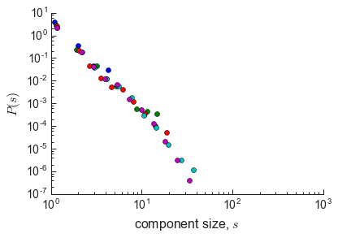

```python
plot_cc_dists(G_sub)
```

We see that the distributions all fall on roughly the same curve--a power law with an exponential cutoff. This is consistent with the book, since remember, the component size distribution in the ER model depends only on the average degree, not on the network size.

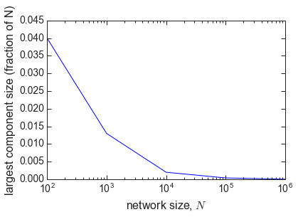

```python
plot_component_scaling(G_sub)
```

We see that asymptotically, the largest component is a negligible fraction of the $N$ nodes. This is consistent with the fact that in the subcritical regime, there is no giant component.

## Critical

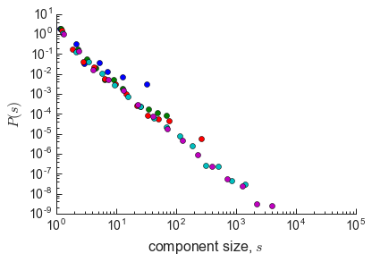

```python
plot_cc_dists(G_crit)
```

Compare this with the above. Again, the size distribution is independent of $N$, but look at the ranges: these curves have much heavier tails than in the subcritical case. A giant component is emerging and the component-size distribution becomes power-law.

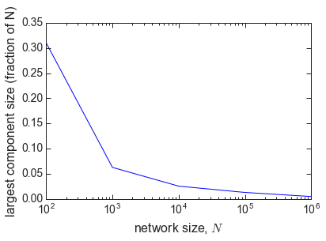

```python
plot_component_scaling(G_crit)
```

This is a little less clear. The largest component size decays slower with $N$, but here there is (theoretically) a giant component, i.e. one that retains a constant size relative to $N$ as $N$ becomes larger and larger. It just so happens that exactlyh at the critical point, that size is near zero! Compare with the phase transition figure in the book.

## Supercritical

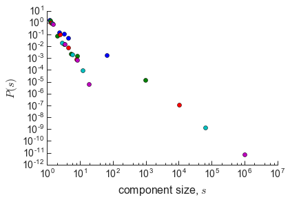

```python
plot_cc_dists(G_super)
```

This looks strange. Let's instead plot without the largest component.

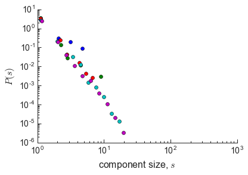

```python
plot_cc_dists(G_super, omit_largest=True)
```

Much clearer. According to the theory for supercritical ER netowrks, the component size distribution is power law with the exception of the largest component, which is a giant component. These are the 5 outliers in the first plot above.

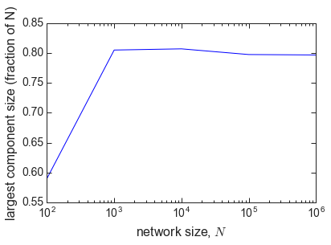

```python
plot_component_scaling(G_super)
```

You see that the largest component size is leveling out at a constant fraction (~0.8) of $N$. That is, the size of the largest component is $\mathcal{O}(N)$

# Don't reinvent the wheel

Now that you understand how some basic graph analysis algorithms work, you should never use them again and instead use the following off-the-shelf commands which are better written and faster.

## Graph generation

- *`erdos_renyi_graph(n, p)`*  
  Generate a random graph. More or less the same as we implemented above.
- *`fast_gnp_random_graph(n, p)`*  
  Much faster for sparse graphs

## Paths and path length

All of the below work on both `Graph` and `DiGraph` objects

- *`has_path(G, source, dest)`*  
  test to see if there is a path (of any length) in G from `source` to `dest`
- *`shortest_path(G, source, dest)`* and *`shortest_path_length(G, source, dest)`*  
  former returns path as a sequence of nodes, latter only returns the length
- *`all_shortest_paths(G, source, dest)`*  
  same as above, but gives ALL shortest paths
- *`single_source_shortest_path(G, source)`* and *`single_source_shortest_path_length(G, source)`*  
  return dictionary `d` where `d[node]` is respectively, the shortest path/path length from `source` to `node`
- *`all_pairs_shortest_path(G)`* and *`all_pairs_shortest_path_length(G)`*  
  return dictionary `d` where `d[node1][node2]` is as above
- *`dijkstra_path(G, source, dest)`* and *`dijkstra_path_length(G, source, dest)`*  
  As above, but for weighted `Graph`/`DiGraph` objects
- *`single_source_dijkstra_path(G, source)`* and *`single_source_dijkstra_path_length(G, source)`*  
  As above, but for weighted `Graph`/`DiGraph` objects

## Searching

All of the below work on both `Graph` and `DiGraph` objects

- *`bfs_tree(G, source)`*  
  Return a Di/Graph representing the tree spanned by a breadth-first search starting at `source`
- *`dfs_tree(G, source)`*  
  Same using depth-first search (gives same result)
- *`all_shortest_paths(G, source, dest)`*  
  same as above, but gives ALL shortest paths

## Connectedness (Undirected)

The below work only on `Graph` objects

- *`is_connected(G)`*  
  `True` or `False` depending on whether `G` is connected or not
- *`connected_components(G)`*  
  Return a list of lists, where each sub-list contains the nodes in one component
- *`number_connected_components(G)`*  
  Returns only the length of the list above
- *`connected_component_sugraphs(G)`*  
  Returns a list of new `Graph` objects each representing a component of `G`
- *`node_connected_component(G, node)`*  
  Return a list of the nodes in the component of `G` containing `node`

## Connectedness (Strong and weak)

The commands below work only on `DiGraph` objects

Note: the `is_weakly_` versions are equivalent to first converting the DiGraph to undirected using G.undirected(), and then running the undirected equivalents above.

- *`is_strongly_connected(G)`*
- *`strongly_connected_components(G)`*
- *`number_strongly_connected_components(G)`*
- *`strongly_connected_component_sugraphs(G)`*
- *`is_weakly_connected(G)`*
- *`weakly_connected_components(G)`*
- *`number_weakly_connected_components(G)`*
- *`weakly_connected_component_sugraphs(G)`*

All are analogous to the undirected case

# Networks with scale-free degree distributions

Remember, the configuration model takes as input a desired degree sequence. It then spits out a network having that degree sequence. So first, we need to be able to randomly generate degrees following a power-law distribution.

```python
def powerlaw_degree_sequence(n, gamma, k_min):
    """ Implements the method for generating power-law distributed numbers
    from uniformly-distributed numbers described in Clauset et al., 2009,
    appendix D"""
    r = np.random.uniform(0, 1, size=n)
    deg = np.floor((k_min-0.5)*(1.0 - r)**(-1.0/(gamma-1)) + 0.5)
    deg = list(map(int, deg))
    return deg
```

```python
def sf_net(n,  gamma, k_min):
    deg = powerlaw_degree_sequence(n, gamma, k_min)
    # sum of all degrees must be even. Why is that?
    if sum(deg) % 2 == 1:
        deg[0] += 1
    G = nx.configuration_model(deg)
    H = nx.Graph(G)
    H.remove_edges_from(H.selfloop_edges())
    return G
```

# Hands-on exercise

- Split into four groups, one each for $\gamma = 2.001, 2.5, 3,$$and$$3.5$
- All groups should use the above code to generate networks of sizes $10^2 \ldots 10^6$ as before with their chosen scaling exponent. Generate all networks with minimum degree cutoff $k_{min}$= 5
- First, measure the maximum degree of each network $k_{max}$, and then plot kmax in log-log scale as a function of $N$
- Next, I want you to plot the average shortest-path distance as a function of $N$ in semi-log scale.
- Note that for larger networks it will be impossible to measure all pairs shortest paths. As an approximation, you should take a random *sample* of pairs of nodes (src, dest), measure the shortest path length between src and dest, and then take the average. Use 100 random node pairs per network.
- Hint 1: `[np.random.choice(G, size=2, replace=False) for _ in range(100)]` will give you a list of 100 random node pairs from G
- Hint 2: You will need to run this within one component. Choose the largest. The following code will sort the components from largest to smallest

`components = sorted(components, key=len, reverse=True)`

You can then use the `subgraph` command on the first component (`components[0]`)

- Hint 3: Use `nx.shortest_path_length` and `nx.connected_components`. They are faster than what we've written.

# Solutions

```python
# Utility functions

def approx_avg_shortest_pl(G, pairs=1000):
    """ Sample the shortest path length for pairs random pairs of nodes and return the average"""
    pl = []
    for _ in range(pairs):
        u, v = np.random.choice(G, size=2, replace=False)
        pl.append(nx.shortest_path_length(G, u, v))
    return np.mean(pl)

def plot_max_degree_scaling(G_list):
    kmax = [max(G.degree().values()) for G in G_list]
    N = [len(G) for G in G_list]
    plt.loglog(N, kmax)
    plt.ylabel(r"maximum degree, $k_{max}$")
    plt.xlabel(r"network size, $N$")

def plot_avg_shortest_pl_scaling(G_list):
    pl = [approx_avg_shortest_pl(G) for G in G_list]
    N = [len(G) for G in G_list]
    plt.semilogx(N, pl)
    plt.ylabel(r"average shortest path length, $\langle d_{ij} \rangle$")
    plt.xlabel(r"network size, $N$")
```

```python
# Generate graphs
k_min = 5
gamma = [2.001, 2.5, 3, 3.5]
N_list = [10**n for n in range(2, 6)]

# create dictionary mapping values of gamma to lists of 5 graphs (one of each size)
G_list = {g:[sf_net(N, g, k_min) for N in N_list] for g in gamma}
```

## $\gamma = 2.001$

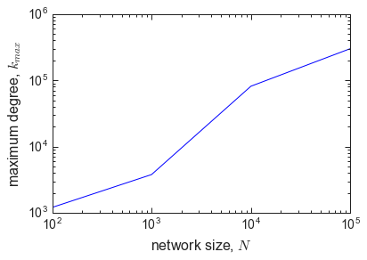

```python
plot_max_degree_scaling(G_list[2.001])
```

This is almost linear in a log-log scale, meaning the maximum degree scales as a power law with the network size (cf. eq. 4.18)

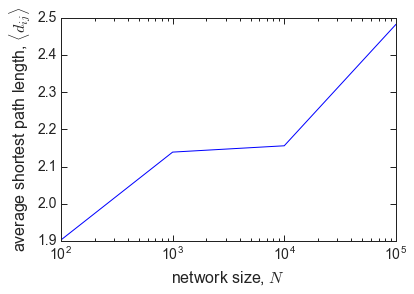

```python
plot_avg_shortest_pl_scaling(G_list[2.001])
```

## $\gamma = 2.5$ is similar

## $\gamma = 3$

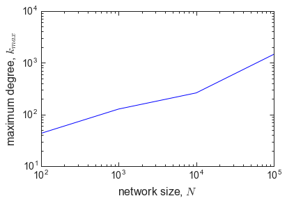

```python
plot_max_degree_scaling(G_list[3.0])
```

Max. degree still scales as a power law with network size. But notice that the raw values of the maximum degree are much lower for each size than for $\gamma = 2.001$ above, reflecting the fact that the distribution is decaying much faster when $\gamma$ is higher.

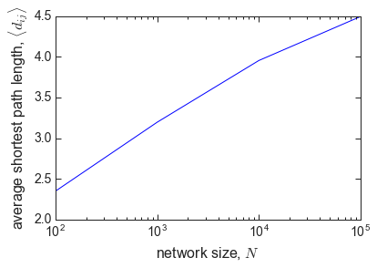

```python
plot_avg_shortest_pl_scaling(G_list[3.0])
```

At the critical point $\gamma = 3$, the avg. shortest path length scales like $log N/log\, log N$.

## $\gamma = 3.5$

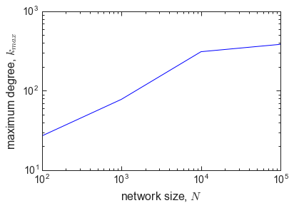

```python
plot_max_degree_scaling(G_list[3.5])
```

Notice how different this is from the cases above. The maximum degree is really not exploding as a function of $N$ anymore.

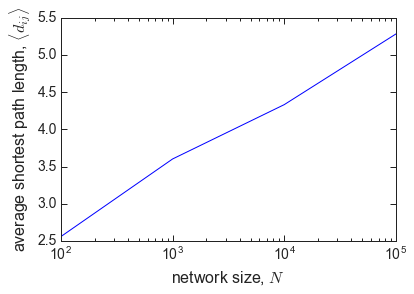

```python
plot_avg_shortest_pl_scaling(G_list[3.5])
```